# COVID-19 Draft

PhD Dejan Mircetic

2020-April-03

$\alpha$ - version

Initial version: 22.03.2020.

Za kreiranje projekcije koriscen je **modifikovani eksponencijalni model**:

[figure not shown]

Matematicki model

Prognoza broja obelelih za period od 22.03 do 31.03, odnosno za za **9 narednih dana**, prikazana je na slici ispod.

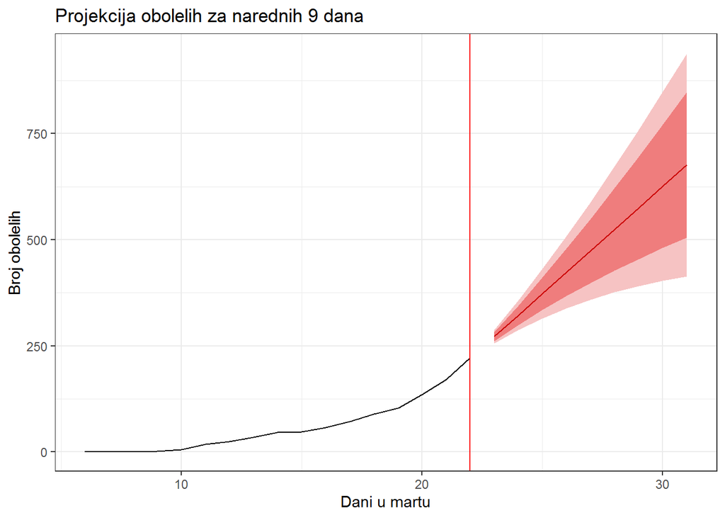

U numerickim vrednostima kretanje broja obolelih moze se ocekivati u sledecim intervalima (scenarijima):

Prognoze po danima

|  | 23.03. | 24.03. | 25.03. | 26.03. | 27.03. | 28.03. | 29.03. | 30.03. | 31.03. |
| --- | --- | --- | --- | --- | --- | --- | --- | --- | --- |
| Najpesimisticniji | 288 | 358 | 431 | 509 | 590 | 673 | 759 | 848 | 939 |
| Ocekivani | 272 | 322 | 373 | 424 | 474 | 525 | 575 | 626 | 676 |
| Najoptimisticniji | 255 | 287 | 315 | 338 | 359 | 376 | 391 | 404 | 414 |

**Najpesimisticniji scenario**: 288, 358, 431, 509, 590, 673, 759, 848, 939

**Ocekivani**: 272, 322, 373, 424, 474, 525, 575, 626, 676

**Najoptimisticniji**: 255, 287, 315, 338, 359, 376, 391, 404, 414

# Ispitivanje tacnosti

**2020-April-03**

Vizaualni prikaz prognoziranog i ostvarenog stanja!

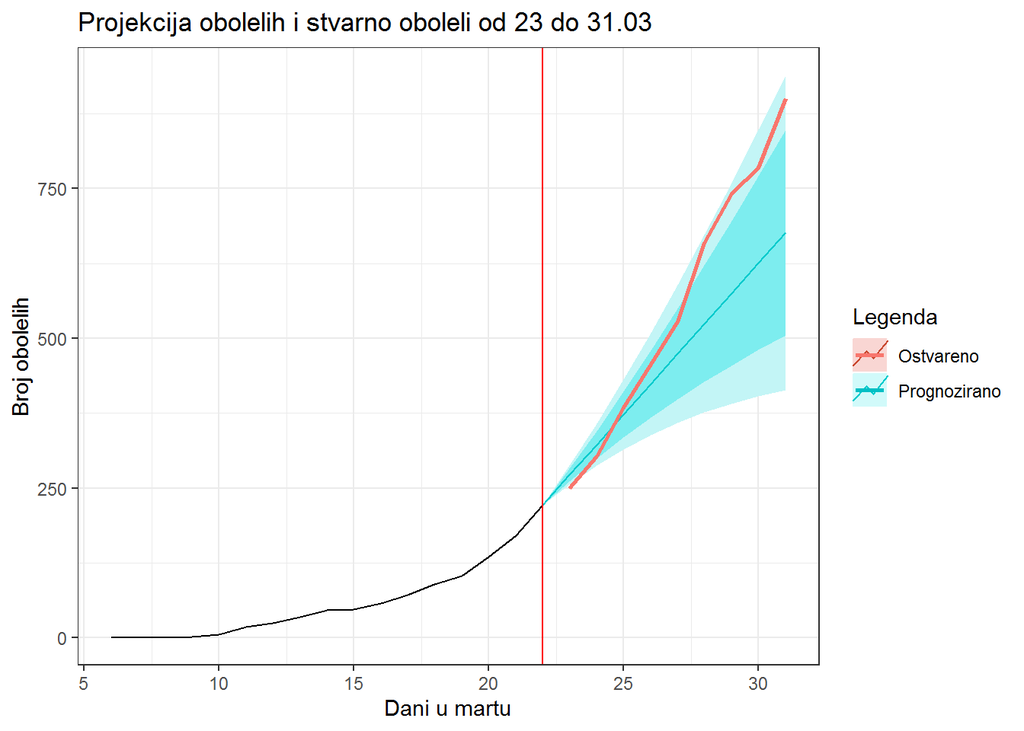

Analitički preciznost iznosi:

Tabela 2. Tacnost prognoziranja.

|  | vrednosti |
| --- | --- |
| ME | 82.13 |
| RMSE | 118.30 |
| MAE | 91.52 |
| MPE | 10.30 |
| MAPE | 13.76 |
| MASE | 6.63 |
| ACF1 | 0.66 |
| Theil’s U | 1.01 |

Iz prethodne tabele uocava se da je model pravio prosjecnu gresku prognoziranja (MAPE) **13.7641399** %.Jedna od greski koja je koriscena u testiranju tacnosti je i nova MASE greska:

$$\text{MASE} = \text{mean}(|q_{j}|).$$
Mase greska iznosila je **6.6258578**.

# Provjeravanje scenaria sa bias adjusted

Ako smo ranije prilagodili prognoze jer su bile pristrasne za 3.1349127. Na osnvou testa ispod vidimo da se rezidulai ne razlikuju od white noise jer je p vrijednost veca od 0.05.

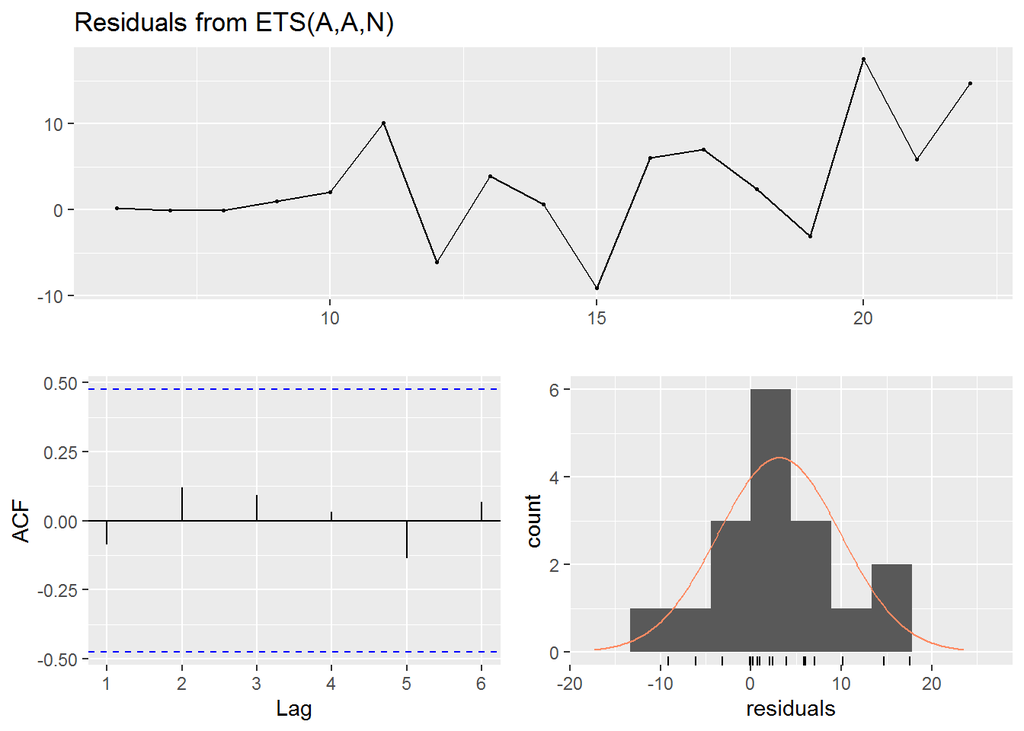

```
##
##  Ljung-Box test
##
## data:  Residuals from ETS(A,A,N)
## Q* = 1.4599, df = 3, p-value = 0.6916
##
## Model df: 4.   Total lags used: 7
```

Tabela 2. Tacnost prognoziranja.

|  | ME | RMSE | MAE | MPE | MAPE | ACF1 | Theil’s U |
| --- | --- | --- | --- | --- | --- | --- | --- |
| Test set | 85.27 | 120.5 | 93.26 | 10.97 | 13.93 | 0.66 | 1.03 |

Vidimo da bi na kraju imali malo vecu MAPE gresku prognoziranja, te da korekcija pristrasnosti nije bila dobra.